# KPR_Network_Analysis.Rmd

Whitney Friedman

2/3/2021

# KPR Network Analysis

This RMD describes and generates the KPR network analysis that is presented in Friedman et al. 2021

2009-2014 Network Analysis - Community structure: How many 2nd order alliances are in this network of (22?) males? - Centrality: – Strength: overall – wStrength: — bStrength vs wStrength: The proportion of each individual’s total strength that is within-group (darker color) versus between-group (lighter color). — bStrengthR: Nodes are sized based on an individual’s relativized between-group strength value (bStrengthR). In each second-order alliance there was one trio with higher bStrength values than other males, indicating that within second-order alliances, one first-order alliance (or possibly a subset of males therein) plays a key role in maintaining third-order alliance relationships

Temporal shifts: T1 (2009-10), T2 (2011-12), T3 (2013-14) To examine the change in alliance relationships through time, we divided the six-year dataset into three two-year periods: 2009-2010 (T1), 2011-2012 (T2), and 2013-2014 (T3). Network measures used to describe differences during these periods include: - Community structure - Centrality (wStrength vs. bStrength)

Modeling Change - Theoretical Knockout - QAP: T1-T2, T2-T3 – Matrix permutation analysis (QAP) demonstrated a significant positive correlation in the networks of KS and PD males persisting between T1 and T2 (r = 0.828, p < 0.001, 5000 permutations). The correlation between the network of KS and PD males persisting through the T2 and T3 periods was lower, though still highly significant (r = 0.757, p < 0.001, 5000 permutations). - wStrength & bStrength: – Comparison of the topological knockout model T2ko to observed shifts between T2 and T3 revealed substantial differences in individual centrality measures. – The T2ko model predicted an increase in mean wStrength for PD males: since two PD males were removed, similar levels of association among fewer males would mean larger mean wStrength values for all remaining members of PD. – No change in mean wStrength was predicted for KS or RR males, since they experienced no change in membership. The observed change shows an overall decrease in mean wStrength for all KS, PD, and RR males (Figure 4A). – The T2ko model predicted a decrease in mean bStrength for KS males, and no change for PD or RR males. – The observed change showed an overall *increase* in mean bStrength in the KPR network except the two first-order allies of the deceased PD male PRI (Figure 4B,C). In summary, PD decreased their within-group associations relative to what was expected, and increased their between-group associations relative to what was expected. Following the loss of their second-order allies, they increased their association frequency with third-order allies. (This demonstrates the dynamic building of alliance relationships over time.)

Key Files in this analysis: - networkStats_PRS.R - networkStats.R - networks_1314.R - networkStats_2y_pub.R

# Setup

```r
library(tidyverse)
library(psych)
library(gridExtra)
library(readxl)
library(janitor)
library(lubridate)
library(here)

#setwd("/Users/friedman/GoogleDriveSync/DAP_sync")

#source("KPR_functions.R")

export_dir <- "/Users/friedman/GoogleDriveSync/DAP_sync/Aerial/Publications/KPR_Network/May2021/"
```

# Load files

## List of IDs and alliances

```r
kpr_ids <-
  read_csv("Aerial/DataAnalysis/Network/KsPdRr09-14/FinalAnalysis/Inputs/KSPDRR_Supplemental.csv") %>%
  clean_names()
kpr_ids
```

```
## # A tibble: 24 x 2
##    id    alliance
##    <chr> <chr>
##  1 BOL   KS
##  2 CEB   KS
##  3 DNG   KS
##  4 DEE   KS
##  5 IMP   KS
##  6 KRO   KS
##  7 MID   KS
##  8 MOG   KS
##  9 NOG   KS
## 10 PAS   KS
## # … with 14 more rows
```

## Centrality measures

- Generated by “networkStats_KPR.R”

```r
source(here("Aerial","DataAnalysis","src","networkStats_KPR.R"))
# Creates tables d0914, d0910, d1112, d1112k, d1314 which contain
# all relevant centrality measures (including new "wStrengthN")
d0910
```

```
## # A tibble: 24 x 20
##    ID    Alliance totKS totPD totRR wStrength bStrength_KPR tStrength_KPR
##    <chr> <chr>    <dbl> <dbl> <dbl>     <dbl>         <dbl>         <dbl>
##  1 BOL   KS        5.3   0.91     0      5.3           0.91          6.21
##  2 CEB   KS        5.28  0.85     0      5.28          0.85          6.13
##  3 DNG   KS        4.35  1.12     0      4.35          1.12          5.47
##  4 DEE   KS        5.17  0.92     0      5.17          0.92          6.09
##  5 IMP   KS        4.74  0.58     0      4.74          0.58          5.32
##  6 KRO   KS        4.12  0.99     0      4.12          0.99          5.11
##  7 MID   KS        4.82  1.63     0      4.82          1.63          6.45
##  8 MOG   KS        4.75  0.83     0      4.75          0.83          5.58
##  9 NOG   KS        4.14  1.33     0      4.14          1.33          5.47
## 10 PAS   KS        5.08  1.2      0      5.08          1.2           6.28
## # … with 14 more rows, and 12 more variables: btStrength_KPR <dbl>,
## #   bStrength_AMA <dbl>, tStrength_AMA <dbl>, EI_KPR_wt <dbl>, wSize <dbl>,
## #   bSize_KPR <dbl>, bStrengthR <dbl>, wStrengthR <dbl>, wStrength_max <dbl>,
## #   wStrengthN <dbl>, bStrength_max <dbl>, bStrengthN <dbl>
```

```r
d0914
```

```
## # A tibble: 22 x 20
##    ID    Alliance totKS totPD totRR wStrength bStrength_KPR tStrength_KPR
##    <chr> <chr>    <dbl> <dbl> <dbl>     <dbl>         <dbl>         <dbl>
##  1 CEB   KS        4.86  0.64  0.49      4.86          1.13          5.99
##  2 DNG   KS        4.46  0.74  0.1       4.46          0.84          5.3
##  3 DEE   KS        4.96  0.67  0.46      4.96          1.13          6.09
##  4 IMP   KS        4.95  0.64  0.37      4.95          1.01          5.96
##  5 KRO   KS        2.85  0.58  0         2.85          0.58          3.43
##  6 MOG   KS        4.82  0.73  0.33      4.82          1.06          5.88
##  7 NOG   KS        4.03  0.84  0         4.03          0.84          4.87
##  8 PAS   KS        4.62  1.15  0.46      4.62          1.61          6.23
##  9 PON   KS        4.93  1.13  0.42      4.93          1.55          6.48
## 10 QUA   KS        4.9   1.17  0.42      4.9           1.59          6.49
## # … with 12 more rows, and 12 more variables: btStrength_KPR <dbl>,
## #   bStrength_AMA <dbl>, tStrength_AMA <dbl>, EI_KPR_wt <dbl>, wSize <dbl>,
## #   bSize_KPR <dbl>, bStrengthR <dbl>, wStrengthR <dbl>, wStrength_max <dbl>,
## #   wStrengthN <dbl>, bStrength_max <dbl>, bStrengthN <dbl>
```

## Load association data

Association files were exported from SOCPROG. The input file was a survey file with group information in which groups - Activity was S/R/T - 5min survey was completed (group was not lost). - Not a resight - See file: “0914_SNA_KPR_Surveys_Final.xlsx” for query and SOCPROG information.

Association data are used to build networks

### Load 09-14 association data

```r
# ama = "All known males associations"
ama0914 <- read_delim(
  here("Aerial", "DataAnalysis","Network", "KsPdRr09-14","FinalAnalysis", "associationMatrices",
       "0914_AMA_Assoc.txt"),
  delim = " ",
  col_names = T) %>%
  clean_names() %>%
  rename(hwi = associations)
ama0914
```

```
## # A tibble: 1,970 x 3
##    from  to      hwi
##    <chr> <chr> <dbl>
##  1 AJA   AGA    0.06
##  2 BAG   AGA    0.78
##  3 BTS   AGA    0.61
##  4 GTO   AGA    0.75
##  5 KRI   AGA    0.06
##  6 MUT   AGA    0.12
##  7 MYR   AGA    0.06
##  8 NAP   AGA    0.6
##  9 OLA   AGA    0.85
## 10 PIK   AGA    0.06
## # … with 1,960 more rows
```

```r
# kpr = krokers, primas, or rascals.
kpr0914 <- ama0914 %>%
  filter(from %in% kpr_ids$id) %>%
  filter(to %in% kpr_ids$id)

kpr0914
```

```
## # A tibble: 372 x 3
##    from  to      hwi
##    <chr> <chr> <dbl>
##  1 BIG   BAR    0.25
##  2 DNG   BAR    0.03
##  3 FRE   BAR    0.24
##  4 NAT   BAR    0.14
##  5 NOG   BAR    0.04
##  6 PAS   BAR    0.06
##  7 PON   BAR    0.07
##  8 PRI   BAR    0.19
##  9 QUA   BAR    0.07
## 10 RID   BAR    0.26
## # … with 362 more rows
```

### Load 09-10 association data

…

### Load 11-12 association data

…

### Load 13-14 KO data

…

### Load 13-14 association data

```r
# ama = "All known males associations"
ama1314 <- read_delim(
  here("Aerial", "DataAnalysis","Network", "KsPdRr09-14","FinalAnalysis","associationMatrices",
       "1314_AMA_Assoc.txt"),
  delim = " ",
  col_names = T) %>%
  clean_names() %>%
  rename(hwi = associations)
ama1314
```

```
## # A tibble: 1,062 x 3
##    from  to      hwi
##    <chr> <chr> <dbl>
##  1 AJA   AGA    0.11
##  2 BAG   AGA    0.91
##  3 BTS   AGA    0.71
##  4 GTO   AGA    0.73
##  5 KRI   AGA    0.11
##  6 MYR   AGA    0.1
##  7 NAP   AGA    0.67
##  8 OLA   AGA    0.91
##  9 PIK   AGA    0.12
## 10 SCM   AGA    0.62
## # … with 1,052 more rows
```

```r
# kpr = krokers, primas, or rascals.
kpr1314 <- ama1314 %>%
  filter(from %in% kpr_ids$id) %>%
  filter(to %in% kpr_ids$id)

kpr1314
```

```
## # A tibble: 302 x 3
##    from  to      hwi
##    <chr> <chr> <dbl>
##  1 CEB   BIG    0.14
##  2 COO   BIG    0.07
##  3 DEE   BIG    0.14
##  4 DNG   BIG    0.09
##  5 FRE   BIG    0.76
##  6 IMP   BIG    0.11
##  7 MOG   BIG    0.14
##  8 NAT   BIG    0.1
##  9 NOG   BIG    0.12
## 10 PAS   BIG    0.17
## # … with 292 more rows
```

# Export seperate 13-14 centrality tables for KS-PD and KS-RR

- Addressing the question: “who are the key players in maintaining the ks&pd (and ks&rr) alliance in 2013-14”
- Looking at the two sets of 3’ allies seperately
- Need to re-calculate bStrengthR & bStrengthN with these smaller groups

```r
# KS & PD:
d1314_kspd <- d1314 %>%
  filter(Alliance %in% c("KS","PD")) %>%
  select(ID, Alliance, totKS, totPD) %>%
  mutate(bSize = case_when(Alliance == "KS" ~ sum(Alliance != "KS"),
                           Alliance == "PD" ~ sum(Alliance != "PD"))) %>%
  mutate(bStrength = case_when(Alliance == "KS" ~ totPD,
                            Alliance == "PD" ~ totKS)) %>%
  mutate(bStrengthR = bStrength/bSize)

bstrength_max_KS <- max(d1314_kspd$bStrength[d1314_kspd$Alliance == "KS"])
bstrength_max_PD <- max(d1314_kspd$bStrength[d1314_kspd$Alliance == "PD"])

d1314_kspd <- d1314_kspd %>%
  mutate(bStrength_max = case_when(Alliance == "KS" ~ bstrength_max_KS,
                                   Alliance == "PD" ~ bstrength_max_PD)) %>%
  mutate(bStrengthN = bStrength/bStrength_max)

d1314_kspd
```

```
## # A tibble: 15 x 9
##    ID    Alliance totKS totPD bSize bStrength bStrengthR bStrength_max
##    <chr> <chr>    <dbl> <dbl> <int>     <dbl>      <dbl>         <dbl>
##  1 CEB   KS        4.6   0.45     5      0.45      0.09           0.87
##  2 DNG   KS        3.57  0.6      5      0.6       0.12           0.87
##  3 DEE   KS        4.81  0.59     5      0.59      0.118          0.87
##  4 IMP   KS        4.6   0.5      5      0.5       0.1            0.87
##  5 KRO   KS        0.25  0        5      0         0              0.87
##  6 MOG   KS        4.42  0.53     5      0.53      0.106          0.87
##  7 NOG   KS        2.72  0.67     5      0.67      0.134          0.87
##  8 PAS   KS        4.59  0.87     5      0.87      0.174          0.87
##  9 PON   KS        4.84  0.68     5      0.68      0.136          0.87
## 10 QUA   KS        4.8   0.77     5      0.77      0.154          0.87
## 11 BIG   PD        1.18  1.79    10      1.18      0.118          1.18
## 12 FRE   PD        1.13  1.82    10      1.13      0.113          1.18
## 13 NAT   PD        1.09  1.29    10      1.09      0.109          1.18
## 14 RID   PD        1.14  1.98    10      1.14      0.114          1.18
## 15 WAB   PD        1.12  1.3     10      1.12      0.112          1.18
## # … with 1 more variable: bStrengthN <dbl>
```

```r
write_csv(d1314_kspd, paste0(export_dir,"centrality_kspd_1314.csv"))


# KS & RR
d1314_ksrr <- d1314 %>%
  filter(Alliance %in% c("KS","RR")) %>%
  select(ID, Alliance, totKS, totRR) %>%
  mutate(bSize = case_when(Alliance == "KS" ~ sum(Alliance != "KS"),
                           Alliance == "RR" ~ sum(Alliance != "RR"))) %>%
  mutate(bStrength = case_when(Alliance == "KS" ~ totRR,
                            Alliance == "RR" ~ totKS)) %>%
  mutate(bStrengthR = bStrength/bSize)


bstrength_max_KS <- max(d1314_ksrr$bStrength[d1314_ksrr$Alliance == "KS"])
bstrength_max_RR <- max(d1314_ksrr$bStrength[d1314_ksrr$Alliance == "RR"])

d1314_ksrr <- d1314_ksrr %>%
  mutate(bStrength_max = case_when(Alliance == "KS" ~ bstrength_max_KS,
                                   Alliance == "RR" ~ bstrength_max_RR)) %>%
  mutate(bStrengthN = bStrength/bStrength_max)

d1314_ksrr
```

```
## # A tibble: 15 x 9
##    ID    Alliance totKS totRR bSize bStrength bStrengthR bStrength_max
##    <chr> <chr>    <dbl> <dbl> <int>     <dbl>      <dbl>         <dbl>
##  1 CEB   KS        4.6   0.91     5      0.91      0.182          0.91
##  2 DNG   KS        3.57  0.21     5      0.21      0.042          0.91
##  3 DEE   KS        4.81  0.83     5      0.83      0.166          0.91
##  4 IMP   KS        4.6   0.69     5      0.69      0.138          0.91
##  5 KRO   KS        0.25  0        5      0         0              0.91
##  6 MOG   KS        4.42  0.6      5      0.6       0.12           0.91
##  7 NOG   KS        2.72  0        5      0         0              0.91
##  8 PAS   KS        4.59  0.82     5      0.82      0.164          0.91
##  9 PON   KS        4.84  0.77     5      0.77      0.154          0.91
## 10 QUA   KS        4.8   0.75     5      0.75      0.15           0.91
## 11 REA   RR        0.24  0.96    10      0.24      0.024          1.77
## 12 COO   RR        1.64  2.47    10      1.64      0.164          1.77
## 13 LAN   RR        0.27  1.93    10      0.27      0.027          1.77
## 14 SMO   RR        1.66  2.49    10      1.66      0.166          1.77
## 15 URC   RR        1.77  2.55    10      1.77      0.177          1.77
## # … with 1 more variable: bStrengthN <dbl>
```

```r
write_csv(d1314_ksrr, paste0(export_dir,"centrality_ksrr_1314.csv"))

kpr1314 %>%
  rename(source = "from",
         target = "to") %>%
  write_csv(paste0(export_dir, "assoc_kpr_1314.csv"))
```

## Barplots

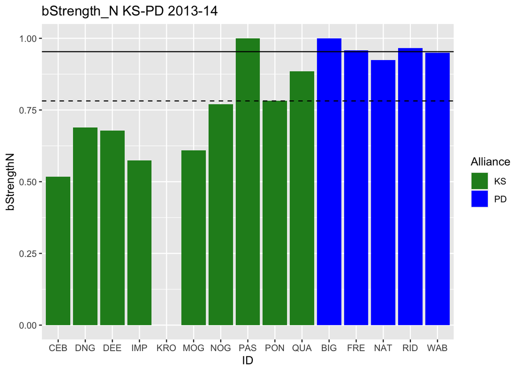

```r
# KS PD 1314
bStrengthN_3q <- summary(d1314_kspd$bStrengthN)[5][[1]]
bStrengthN_median <- summary(d1314_kspd$bStrengthN)[3][[1]]

# Dashed line = median; Solid line = 3rd Quartile
kspd_plt <- d1314_kspd %>%
  mutate(ID = factor(ID, levels = kpr_ids$id)) %>%
  ggplot(aes(x=ID,y=bStrengthN, fill = Alliance)) +
    geom_bar(stat = "identity") +
    scale_fill_manual(values=c("forestgreen","blue"))+
    geom_hline(yintercept = bStrengthN_3q) +
    geom_hline(yintercept = bStrengthN_median, linetype = "dashed")+
    ggtitle("bStrength_N KS-PD 2013-14")

kspd_plt
```

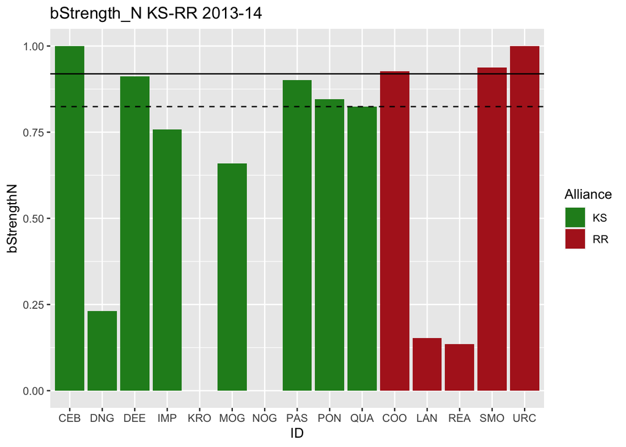

```r
# KS RR 1314
bStrengthN_3q <- summary(d1314_ksrr$bStrengthN)[5][[1]]
bStrengthN_median <- summary(d1314_ksrr$bStrengthN)[3][[1]]

# Dashed line = median; Solid line = 3rd Quartile
ksrr_plt <- d1314_ksrr %>%
  mutate(ID = factor(ID, levels = kpr_ids$id)) %>%
  ggplot(aes(x=ID,y=bStrengthN, fill = Alliance)) +
    geom_bar(stat = "identity") +
    scale_fill_manual(values=c("forestgreen","firebrick"))+
    geom_hline(yintercept = bStrengthN_3q) +
    geom_hline(yintercept = bStrengthN_median, linetype = "dashed") +
    ggtitle("bStrength_N KS-RR 2013-14")

ksrr_plt
```

```r
ggsave("ksrr_1314_barplot.pdf", plot = ksrr_plt, device = "pdf",
       path = export_dir, width = 8, height = 5)

ggsave("kspd_1314_barplot.pdf", plot = kspd_plt, device = "pdf",
       path = export_dir, width = 8, height = 5)
```

# Create Networks

## Load libraries for network visualization

```r
library(igraph)
library(ggraph)
```

## 09-14 KPR Network

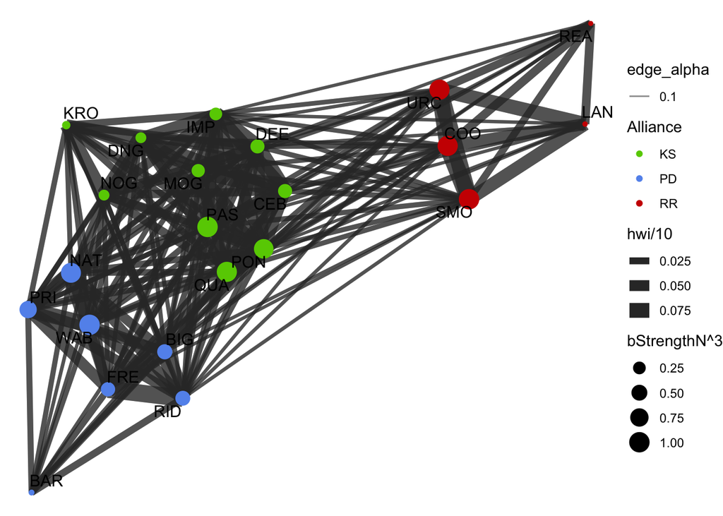

```r
edge_df <- kpr0914
node_df <- d0914 %>%
  rename(name = ID)

network <- edge_df %>%
  drop_na() %>%
  graph_from_data_frame(directed = F, vertices = node_df)

#plot(network) # basic plot

# size by bStrengthN
set.seed(1986)
g_plt <- ggraph(network, layout = 'fr', weights = hwi)+
    geom_edge_link(aes(width = hwi/10, alpha=0.1), edge_colour="grey20")+
    #geom_edge_link(aes(alpha = .5),edge_colour="grey25")+
    #geom_node_point()+
    geom_node_point(aes(colour = Alliance, size=bStrengthN^3)) +
    scale_colour_manual(values=c("chartreuse3","cornflowerblue","red3"))+
    geom_node_text(aes(label = name), repel = T, size=4)+
    theme_void()

g_plt
```

```r
pdf(here("Aerial","Publications","KPR_Network",
         "April2020", "outputs","kpr_0914_ggraph.pdf"),
    height = 8, width = 10)
plot(g_plt)
dev.off()
```

## 13-14 KS-PD and KS-RR networks

- Create separate networks for KS-PD and KS-RR for the 2013-14 period

### visNetwork for 13-14 KPR

https://datastorm-open.github.io/visNetwork/ https://www.r-bloggers.com/2019/06/interactive-network-visualization-with-r/

```r
library(visNetwork)
library(htmlwidgets)

id_list <- kpr_ids %>%
  #filter(!id %in% c("BOL","MID","KRO","NOG")) %>%
  filter(!id %in% c("BOL","MID")) %>%
  select(id) %>% pull()
```

```r
edge_df <- kpr1314 %>%
  filter(from %in% id_list) %>%
  filter(to %in% id_list) %>%
  mutate(width = hwi*10,
         label = hwi)

node_df <- d1314 %>%
  clean_names() %>%
  filter(id %in% id_list) %>%
  mutate(label = id,
         value = b_strength_n,
         color = case_when(alliance == "KS" ~ "forestgreen",
                           alliance == "PD" ~ "cornflowerblue",
                           alliance == "RR" ~ "red"),
         shadow = F)

# works but not as informative:
# visNetwork(node_df, edge_df) %>%
#  visPhysics(solver = "forceAtlas2Based",
#           forceAtlas2Based = list(gravitationalConstant = -50,
#                                   avoidOverlap = .1))


vn <- visNetwork(node_df, edge_df, width = "100%", main = "KPR 2013-14") %>%
  visIgraphLayout(layout = "layout_nicely") %>%
  #visIgraphLayout(layout = "layout_in_circle") %>%
  visNodes(size = 10) %>%
  visEdges(color = list(color = "lightblue",highlight ="black")) %>%
  visOptions(highlightNearest = list(enabled = T, degree = 1, hover = T),
             selectedBy = "id") %>%
  visLayout(randomSeed = 11)

vn
```

[interactive chart not shown]

```r
saveWidget(vn, "/Users/friedman/Documents/Projects/Websharing/wrfriedman.github.io/dap/kpr_1314_v2.html")
```

### External ties only (KPR network)

- 13-14 KPR network showing ONLY external ties.
- If alliance is KS, remove all KS ties. etc.

```r
edge_df <- kpr1314 %>%
  filter(from %in% id_list) %>%
  filter(to %in% id_list) %>%
  mutate(width = hwi*10,
         label = hwi) %>%
  left_join(kpr_ids %>%
              mutate(from = id,
                     from_alliance = alliance) %>%
              select(from, from_alliance),
            by = "from") %>%
  left_join(kpr_ids %>%
              mutate(to = id,
                     to_alliance = alliance) %>%
              select(to, to_alliance),
            by = "to") %>%
  # remove all internal network ties
  mutate(same_alliance = case_when(from_alliance == to_alliance ~ 1,
                                   TRUE ~ 0)) %>%
  filter(same_alliance == 0)

node_df <- d1314 %>%
  clean_names() %>%
  filter(id %in% id_list) %>%
  mutate(label = id,
         value = b_strength_n,
         color = case_when(alliance == "KS" ~ "forestgreen",
                           alliance == "PD" ~ "cornflowerblue",
                           alliance == "RR" ~ "red"),
         shadow = F)



vn <- visNetwork(node_df, edge_df, width = "100%", main = "KPR 2013-14 External Ties") %>%
  #visIgraphLayout(layout = "layout_in_circle") %>%
  visIgraphLayout(layout = "layout_with_kk") %>%
  #visPhysics(solver = "forceAtlas2Based",
  #           forceAtlas2Based = list(gravitationalConstant = -20,
  #                                   avoidOverlap = .1)) %>%
  visNodes(size = 2) %>%
  visEdges(color = list(color = "lightblue",highlight ="black")) %>%
  visOptions(highlightNearest = list(enabled = T, degree = 1, hover = T),
             selectedBy = "id") %>%
  visLayout(randomSeed = 11)

vn
```

[interactive chart not shown]

```r
saveWidget(vn, "/Users/friedman/Documents/Projects/Websharing/wrfriedman.github.io/dap/kpr_1314.html")
```

```r
# Heatmap

hwi_table  <- kpr1314

hwi_ordered_table <- hwi_table %>%
  mutate(from = factor(from,
                          levels = kpr_ids$id,
                          ordered = T),
         to = factor(to,
                     levels = kpr_ids$id,
                     ordered = T))

hwi_heatmap <- ggplot(hwi_ordered_table, aes(from, to)) +
    geom_tile(aes(fill = log1p(hwi))) +
    geom_text(aes(label = round(hwi, 2)),size =2) +
    scale_fill_gradient(low = "white", high = "red")


# Local
pdf(here("Aerial","Publications","KPR_Network",
         "May2021","kpr_1314_heatmap.pdf"),
    height = 10, width = 10)
plot(hwi_heatmap)
dev.off()
```

```r
# Share to web
pdf("/Users/friedman/Documents/Projects/Websharing/wrfriedman.github.io/dap/kpr_1314_heatmap.pdf",
    height = 10, width = 10)
plot(hwi_heatmap)
dev.off()
```

### visNetwork for 13-14 *KS-PD ONLY!

```r
id_list <- kpr_ids %>%
  filter(alliance %in% c("KS","PD")) %>%
  #filter(!id %in% c("PRI","BOL","MID","KRO","NOG")) %>%
  select(id) %>% pull()

id_list
```

```
##  [1] "BOL" "CEB" "DNG" "DEE" "IMP" "KRO" "MID" "MOG" "NOG" "PAS" "PON" "QUA"
## [13] "BAR" "BIG" "FRE" "NAT" "PRI" "RID" "WAB"
```

```r
edge_df <- kpr1314 %>%
  filter(from %in% id_list) %>%
  filter(to %in% id_list) %>%
  mutate(width = hwi*10,
         label = hwi)

node_df <- d1314_kspd %>%
  clean_names() %>%
  filter(id %in% id_list) %>%
  mutate(label = id,
         value = exp(b_strength_n),
         color = case_when(alliance == "KS" ~ "forestgreen",
                           alliance == "PD" ~ "cornflowerblue",
                           alliance == "RR" ~ "red"),
         shadow = F)


vn_kspd <- visNetwork(node_df, edge_df, width = "100%", main = "KS-PD 2013-14") %>%
  visIgraphLayout(layout = "layout_with_mds", physics = T, randomSeed = 1986) %>%
  visPhysics(solver = "forceAtlas2Based",
            forceAtlas2Based = list(gravitationalConstant = -500,
                                    avoidOverlap = .5)) %>%
  visNodes() %>%
  visEdges(color = list(color = "darkseagreen",highlight ="black")) %>%
  visOptions(highlightNearest = list(enabled = T, degree = 1, hover = T),
             selectedBy = "id")

vn_kspd
```

[interactive chart not shown]

```r
saveWidget(vn_kspd, "/Users/friedman/Documents/Projects/Websharing/wrfriedman.github.io/dap/kspd_1314.html")
```

### visNetwork for 13-14 *KS-RR ONLY

```r
id_list <- kpr_ids %>%
  filter(alliance %in% c("KS","RR")) %>%
  #filter(!id %in% c("PRI","BOL","MID","KRO","NOG")) %>%
  select(id) %>% pull()

id_list
```

```
##  [1] "BOL" "CEB" "DNG" "DEE" "IMP" "KRO" "MID" "MOG" "NOG" "PAS" "PON" "QUA"
## [13] "COO" "LAN" "REA" "SMO" "URC"
```

```r
edge_df <- kpr1314 %>%
  filter(from %in% id_list) %>%
  filter(to %in% id_list) %>%
  mutate(width = hwi*10,
         label = hwi)

node_df <- d1314_ksrr %>%
  clean_names() %>%
  filter(id %in% id_list) %>%
  mutate(label = id,
         value = exp(b_strength_n),
         color = case_when(alliance == "KS" ~ "forestgreen",
                           alliance == "PD" ~ "cornflowerblue",
                           alliance == "RR" ~ "red"),
         shadow = F)


vn_ksrr <- visNetwork(node_df, edge_df, width = "100%", main = "KS-RR 2013-14") %>%
  visIgraphLayout(layout = "layout_with_mds", physics = T, randomSeed = 1986) %>%
  visPhysics(solver = "forceAtlas2Based",
            forceAtlas2Based = list(gravitationalConstant = -500,
                                    avoidOverlap = .1)) %>%
  visNodes() %>%
  visEdges(color = list(color = "lightblue",highlight ="black")) %>%
  visOptions(highlightNearest = list(enabled = T, degree = 1, hover = T),
             selectedBy = "id")

vn_ksrr
```

[interactive chart not shown]

```r
saveWidget(vn_ksrr, "/Users/friedman/Documents/Projects/Websharing/wrfriedman.github.io/dap/ksrr_1314.html")

# Export for gephi
#visNetwork(gephi = 'WorldCup2014.json')
```